# MSD 2019 Final Project

A replication and extension of by Jure Leskovec, Daniel Huttenlocher, and John Kleinberg, WWW 2010: ACM WWW International conference on World Wide Web, 2010

Sameer Jain (sj2736), Bailey Pierson (bp2471), Tanmay Chopra (tc2897)

## INTRODUCTION

This project reproduces sections of Leskovec et. al’s 2010 paper [Predicting Positive and Negative Links in Online Social Networks](https://www.cs.cornell.edu/home/kleinber/www10-signed.pdf), then extends their analysis to two new data sets in order to further investigate claims of underlying social-psychological laws of signed edge formation. We first provide brief summary of the paper, then provide technical details behind the collection of data and generation of node-level model features. We combine these features following the analytic framework presented by Leskovec et. al, and provide an analysis of the divergences between these replicated results and those presented in the paper. Our primary replicated results include a comparision of predicted accuracy across domains and varying embeddedness thresholds, and a tabulation of cross-domain model generalizability. There are significant differences between replicated and published results, but no evidence which directly refutes the claims of the paper. Our extension introduces a newly collected data set– a Wikipedia adminship voting network through May 2019– and also incorporates another signed trust network derived from Bitcoin user behavior. Ultimately, these extensions suggest clear limitations to Leskovec et. al’s attempts to assert that balance and status theories can reveal immutable psychological laws which underlie the creation of social networks and allow for generalization across signed trust networks.

## MOTIVATIONS

Leskovec et. al (2010) deals with two fundamental tasks: **edge sign prediction** and **generalization**. Edge sign prediction is formulated as follows. Suppose that we are given a social network with signs on all of its edges, but the sign from node $u$ to node $v$ has been hidden. How can we reliably infer the sign of this edge given information provided by the rest of the network? The authors approach this question using a logistic regression framework which allows for the combination of a range of structural features at the node- and triad-level in order to predict a binary edge sign. The investigation of this problem across a range of data sets leads to the consideration of the generalizability of models. Generalization is measured by the sign prediction performance of a model trained on one domain and tested on another. Remarkably, the authors’ find that performance only degrades slightly in cross-domain testing, which encourages them to incorporate social-psychological theories of status and balance in their discussion. Ultimately, the inclusion of these theories motivates a claim that there are underlying behavioral rules which produce cross-domain consistencies in the structure of signed trust networks.

## REPRODUCTION

### Data Collection

The paper under replication considers from three large online social networks – Epinions, Slashdot, and Wikipedia. As part of our extension of the study, we also supplement the provided Wikipedia data with new data extending up to May 2019 and data from a network of Bitcoin traders. All of these data sets include edges which are explicitly signed as positive or negative.

#### Epinions, Slashdot & Bitcoin

The edge lists for network data from Epinions, Slashdot, and Bitcoin are publicly accessible on the [Stanford Network Analysis Project (SNAP)](https://snap.stanford.edu/index.html). Using data pulled directly from SNAP, our [Epinions](https://snap.stanford.edu/data/soc-Epinions1.html) data has 841,371 edges and 119,845 nodes, which are both slightly higher than the 841,000 edges and 119,217 nodes recorded for this data set in Leskovec et. al (2010). Epinions was a product review site (defunct as of 2012) which allowed users to note whether they trusted or distrusted the reviews of another user on the site. This data spans from the conception of the site in 1999 until August 2003.

The [Slashdot](https://snap.stanford.edu/data/soc-Slashdot0902.html) data we have pulled from SNAP has 549,202 edges and 82,144 nodes, which corresponds directly which the data reported in the paper. Slashdot is a tech news website which allows users to tag each other as “friend” or “foe” based on an individual’s opinions on the comments another user contributes to the site. This data set spans from 2002 to February 2009

The [Bitcoin](https://snap.stanford.edu/data/soc-sign-bitcoin-otc.html) dataset was also found on SNAP, and is signed network where an edge constitutes a measure of trust between users. This network was collected from the activity of people who trade using Bitcoin on a platform called Bitcoin OTC. As bitcoin users are anonymous, there is a need to record users’ reputation to prevent transactions with fraudulent users. Members of Bitcoin OTC rate other members in a scale of -10 (total distrust) to +10 (total trust) in steps of 1. In order to standardize the prediction framework across domains, this scale of trust is re coded to a binary 0 or 1 value where negative edges are coded and 0, and positive edges as 1. This dataset contains 5,881 nodes and 35,592 edges.

The collection of these data sets into a clean edge list format was straightforward. After decompressing files from SNAP, unnecessary string characters were stripped from the start of files, and non-UTF characters where then removed. The code used to clean these files is included in the `nodeFeatures.py` file.

#### Wikipedia

*Old Wikipedia*

Wikipedia is a very popular collectively authored online encyclopedia. A network data set is developed from the user application process for applying for adminship. In order to become an admin on the site, a user is either nominated by other admins, or self-nominates, then other Wikipedia users are able to cast a support, oppose, or neutral vote. While not specified in the paper, after investigation we determined that neutral edges are excluded from analysis, so a signed link in this data set indicates a positive or negative vote by a user on another user’s promotion to adminship status. The Wikipedia data associated with this paper on SNAP includes all adminship votes up to January 2008. While the paper states this data contains 103,747 edges and 7,118 nodes, the data set we pulled directly from SNAP has 110,086 edges and 7194 nodes.

The collection of this data into a clean edge list was somewhat more complex, as it’s initial structure was a *rough* approximation of an adjacency list. The code used to restructure this file is included in the `nodeFeatures.py` file.

*New Wikipedia*

Unfortunately, Leskovec et. al (2010) make no mention of how they extracted adminship network data from the 2008 data dump of the entirety of Wikipedia, and despite that fact they are explicitly mentioned in the paper as publicly available, no replication scripts were able to be found on SNAP or on the author’s personal websites/GitHub accounts. Therefore, in order to collect new Wikipedia adminship data, a web scraper was written in order to pull out all votes on adminship requests from the conception of the adminship application process until May 2019. Exactly as specified in the paper, a edge between two users in this network is directed, and represents the support/oppose vote of one user on the promotion of another user to adminship. The script used to identify all pages associated with applications for adminship is `getPageId.py`; the script which implements a web scraper and writes voting behavior to an edge list is `getEdgelist.py`. This new Wikipedia adminship data set has a total of 11,581 nodes and 130,915 edges.

### Feature Generation

After consulting with Jake, it was determined that we would reproduce the seven primary node-level features used by Leskovec et. al in their edge prediction task. These features include:

1. $d^{+}_{in}(u)$, the number of incoming positive edges to node $u$ which has the directed edge $u \rightarrow v$
2. $d^{-}_{in}(v)$, the number of incoming negative edges to node $v$ which has the directed edge $u \rightarrow v$
3. $d^{+}_{out}(u)$, the number of outgoing positive edges to node $u$ which has the directed edge $u \rightarrow v$
4. $d^{-}_{out}(v)$, the number of outgoing negative edges to node $v$ which has the directed edge $u \rightarrow v$
5. $d^{+}_{out}(u) + d^{-}_{out}(u)$, or the total out degree of $u$
6. $d^{+}_{in}(v) + d^{-}_{in}(v)$, or the total in degree of $v$
7. $C(u,v)$, the *embeddedness* of edge $(u,v)$ or the total number of common neighbors of $u$ and $v$ in an un-directed sense

All of these features are computed for each data set using the scripts found in the `nodeFeatures.py` file.

### Analysis and Visualization

```r
#helper function for fitting logit models
embedding_loop <- function(temp_test, em_level) {

  temp_test <- temp_test %>% filter(embeddedness >= em_level)

  mylogit <- glm(sign ~ embeddedness + pos_in.x + neg_in.y + total_out.x + total_in.y + pos_out.x + neg_out.y, data = temp_test, family = "binomial")
  summary(mylogit)

  temp_x <- temp_test[,-c(1,2,3)]
  temp_y <- temp_test[,3]
  cvfitted <- cv.glmnet(as.matrix(temp_x),temp_y, family="binomial")

  print(cvfitted$lambda.min)

  log_odds_predictions <-predict(cvfitted,as.matrix(temp_x), s="lambda.min")
  prob_predictions <- exp(log_odds_predictions)/(1 + exp(log_odds_predictions))
  prob_predictions_actual <- cbind(prob_predictions, temp_y)
  colnames(prob_predictions_actual) <- c("probability","actual")

  prob_predictions_actual <- as_tibble(prob_predictions_actual)
  prob_predictions_actual <- prob_predictions_actual %>%
    mutate(predicted_sign =  ifelse(probability < .5, 0, 1)) %>%
    mutate(match = ifelse(predicted_sign == actual, 1,0))

  print(mean(prob_predictions_actual$match))
  return(mean(prob_predictions_actual$match))
}
```

```r
# run logit for old wikipedia data
oldwiki_edges <- read.csv("data/oldwiki_edgelist.csv", col.names = c("u", "v", "sign"))
oldwiki_nodes <-read_csv("data/nodes_features_oldwiki.csv")
oldwiki_embed <-read_csv("data/edges_features_old_wiki.csv")

oldwiki_sign_embed <- inner_join(oldwiki_edges, oldwiki_embed, by = c('u'='u', 'v' = 'v'))
oldwiki_sign_embed <- inner_join(oldwiki_sign_embed, oldwiki_nodes, by = c('u' = 'node_id'))
oldwiki_sign_embed <- inner_join(oldwiki_sign_embed, oldwiki_nodes, by = c('v' = 'node_id'))
test <- select(oldwiki_sign_embed, u, v, sign, embeddedness, pos_in.x, neg_in.y, total_out.x, total_in.y, pos_out.x, neg_out.y)

test <- test %>% filter(sign != 0) %>% mutate(sign =  ifelse(sign == -1, 0, 1))

#compute predictive accruacy for embeddedness at 0, 10, 25
pred_accuracy_oldwiki <- vector('numeric', 3)
pred_accuracy_oldwiki[1] <- embedding_loop(test, 0)
```

```
## [1] 0.0001775191
## [1] 0.8548701
```

```r
pred_accuracy_oldwiki[2] <- embedding_loop(test, 10)
```

```
## [1] 0.000184935
## [1] 0.867467
```

```r
pred_accuracy_oldwiki[3] <- embedding_loop(test, 25)
```

```
## [1] 0.0001963528
## [1] 0.8791778
```

```r
# run logit for slashdot data
slashdot_edges <- read.csv("data/edgelist_slashdot.csv", col.names = c("u", "v", "sign"))
slashdot_nodes <-read_csv("data/nodes_features_slashdot.csv")
slashdot_embed <-read_csv("data/edges_features_slashdot.csv")

slashdot_sign_embed <- inner_join(slashdot_edges, slashdot_embed, by = c('u'='u', 'v' = 'v'))
slashdot_sign_embed <- inner_join(slashdot_sign_embed, slashdot_nodes, by = c('u' = 'node_id'))
slashdot_sign_embed <- inner_join(slashdot_sign_embed, slashdot_nodes, by = c('v' = 'node_id'))
test_slashdot <- select(slashdot_sign_embed, u, v, sign, embeddedness, pos_in.x, neg_in.y, total_out.x, total_in.y, pos_out.x, neg_out.y)

test_slashdot <- test_slashdot %>% filter(sign != 0) %>% mutate(sign =  ifelse(sign == -1, 0, 1))

#compute predictive accruacy for embeddedness at 0, 10, 25
pred_accuracy_slashdot <- vector('numeric', 3)
pred_accuracy_slashdot[1] <- embedding_loop(test_slashdot, 0)
```

```
## [1] 0.0002660391
## [1] 0.8424392
```

```r
pred_accuracy_slashdot[2] <- embedding_loop(test_slashdot, 10)
```

```
## [1] 0.0002428054
## [1] 0.9294612
```

```r
pred_accuracy_slashdot[3] <- embedding_loop(test_slashdot, 25)
```

```
## [1] 0.000156232
## [1] 0.9646173
```

```r
# run logit for epinions data
epinions_edges <- read.csv("data/edgelist_epinions.csv", col.names = c("u", "v", "sign"))
epinions_nodes <-read_csv("data/nodes_features_epinions.csv")
epinions_embed <-read_csv("data/edges_features_epinions.csv")

epinions_sign_embed <- inner_join(epinions_edges, epinions_embed, by = c('u'='u', 'v' = 'v'))
epinions_sign_embed <- inner_join(epinions_sign_embed, epinions_nodes, by = c('u' = 'node_id'))
epinions_sign_embed <- inner_join(epinions_sign_embed, epinions_nodes, by = c('v' = 'node_id'))
test_epinions <- select(epinions_sign_embed, u, v, sign, embeddedness, pos_in.x, neg_in.y, total_out.x, total_in.y, pos_out.x, neg_out.y)

test_epinions <- test_epinions %>% filter(sign != 0) %>% mutate(sign =  ifelse(sign == -1, 0, 1))

#compute predictive accruacy for embeddedness at 0, 10, 25
pred_accuracy_epinions <- vector('numeric', 3)
pred_accuracy_epinions[1] <- embedding_loop(test_epinions, 0)
```

```
## [1] 0.0001184679
## [1] 0.8990697
```

```r
pred_accuracy_epinions[2] <- embedding_loop(test_epinions, 10)
```

```
## [1] 0.0002127045
## [1] 0.9349311
```

```r
pred_accuracy_epinions[3] <- embedding_loop(test_epinions, 25)
```

```
## [1] 0.0002379483
## [1] 0.9378034
```

### Figure 1

```r
# produce figure for comparision across domains
pred_acc_chunk_ep <- cbind(c("0","10","25"), pred_accuracy_epinions, c("epinions", "epinions", "epinions"))
pred_acc_chunk_sl <- cbind(c("0","10","25"), pred_accuracy_slashdot, c("slashdot", "slashdot", "slashdot"))
pred_acc_chunk_ow <- cbind(c("0","10","25"), pred_accuracy_oldwiki, c("oldwiki", "oldwiki", "oldwiki"))
reformatted_pred_acc <- rbind(pred_acc_chunk_ep, pred_acc_chunk_sl, pred_acc_chunk_ow)
reformatted_pred_acc <- as_tibble(reformatted_pred_acc)

colnames(reformatted_pred_acc) <- c("embed", "predacc", "website")
reformatted_pred_acc <- reformatted_pred_acc %>%
  mutate(predacc = as.numeric(predacc))
```

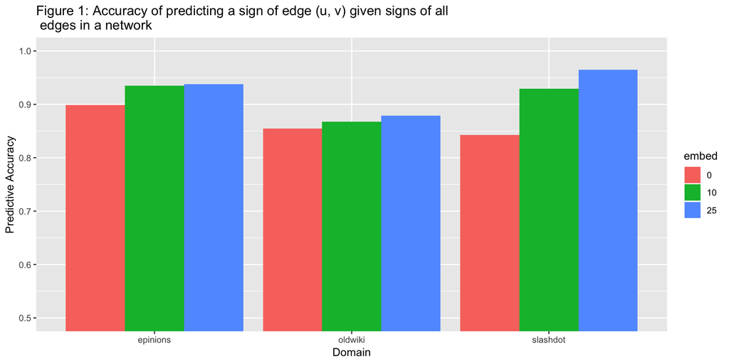

```r
ggplot(data = reformatted_pred_acc, aes(website, predacc)) +
  geom_bar(aes(fill = embed), position = "dodge", stat = "identity") +
  coord_cartesian(ylim=c(.5, 1)) +
  labs(y = 'Predictive Accuracy', x = 'Domain', title = 'Figure 1: Accuracy of predicting a sign of edge (u, v) given signs of all \n edges in a network')
```

### Table 6

```r
#helper function for cross-prediction
cross_predict <- function(model, temp_test) {

  temp_x <- temp_test[,-c(1,2,3)]
  temp_y <- temp_test[,3]

  log_odds_predictions <-predict(model,as.matrix(temp_x), s="lambda.min")
  prob_predictions <- exp(log_odds_predictions)/(1 + exp(log_odds_predictions))
  prob_predictions_actual <- cbind(prob_predictions, temp_y)
  colnames(prob_predictions_actual) <- c("probability","actual")

  prob_predictions_actual <- as_tibble(prob_predictions_actual)
  prob_predictions_actual <- prob_predictions_actual %>%
    mutate(predicted_sign =  ifelse(probability < .5, 0, 1)) %>%
    mutate(match = ifelse(predicted_sign == actual, 1,0))

  cf <-confusionMatrix(table(prob_predictions_actual$predicted_sign,prob_predictions_actual$actual))
  print(as.table(cf))

  print(mean(prob_predictions_actual$match))
  return(mean(prob_predictions_actual$match))
}
```

```r
#train logits for cross-domain prediction
temp_x1 <- test[,-c(1,2,3)]
temp_x2 <- test_epinions[,-c(1,2,3)]
temp_x3 <- test_slashdot[,-c(1,2,3)]

temp_y1 <- test[,3]
temp_y2 <- test_epinions[,3]
temp_y3 <- test_slashdot[,3]

mylogit_wiki_old <- cv.glmnet(as.matrix(temp_x1),temp_y1, family = "binomial")
mylogit_epinions <- cv.glmnet(as.matrix(temp_x2),temp_y2, family = "binomial")
mylogit_slashdot <-cv.glmnet(as.matrix(temp_x3),temp_y3, family = "binomial")
```

```r
## cross=domain prediction
cross_predict(mylogit_wiki_old,test_epinions)
```

```
##
##          0      1
##   0  63125   9876
##   1  17453 273520
## [1] 0.924915
```

```
## [1] 0.924915
```

```r
cross_predict(mylogit_wiki_old,test_slashdot)
```

```
##
##          0      1
##   0  38262  19741
##   1  15677 154232
## [1] 0.8445979
```

```
## [1] 0.8445979
```

```r
cross_predict(mylogit_slashdot,test)
```

```
##
##         0     1
##   0  1727   386
##   1 14383 52835
## [1] 0.7869784
```

```
## [1] 0.7869784
```

```r
cross_predict(mylogit_slashdot,test_epinions)
```

```
##
##          0      1
##   0  46503   5361
##   1  34075 278035
## [1] 0.8916516
```

```
## [1] 0.8916516
```

```r
cross_predict(mylogit_epinions,test)
```

```
##
##         0     1
##   0  5461  3521
##   1 10649 49700
## [1] 0.7956181
```

```
## [1] 0.7956181
```

```r
cross_predict(mylogit_epinions,test_slashdot)
```

```
##
##          0      1
##   0  21438  10230
##   1  32501 163743
## [1] 0.812511
```

```
## [1] 0.812511
```

## EXTENSION

### New Wikipedia Data and Bitcoin Network Data

```r
# compute accuracy across embeddedness for new wikipedia data

newwiki_edges <- read.csv("data/edgelist_newwiki.csv", col.names = c("u", "v", "sign"))
newwiki_nodes <-read_csv("data/nodes_features_newwiki.csv")
newwiki_embed <-read_csv("data/edges_features_new_wiki.csv")

newwiki_sign_embed <- inner_join(newwiki_edges, newwiki_embed, by = c('u'='u', 'v' = 'v'))
newwiki_sign_embed <- inner_join(newwiki_sign_embed, newwiki_nodes, by = c('u' = 'node_id'))
newwiki_sign_embed <- inner_join(newwiki_sign_embed, newwiki_nodes, by = c('v' = 'node_id'))

test_newwiki <- select(newwiki_sign_embed, u, v, sign, embeddedness, pos_in.x, neg_in.y, total_out.x, total_in.y, pos_out.x, neg_out.y)

test_newwiki <- test_newwiki %>% filter(sign != 0) %>% mutate(sign =  ifelse(sign == -1, 0, 1))

pred_accuracy_newwiki <- vector('numeric', 3)
pred_accuracy_newwiki[1] <- embedding_loop(test, 0)
```

```
## [1] 0.0001775191
## [1] 0.8548701
```

```r
pred_accuracy_newwiki[2] <- embedding_loop(test, 10)
```

```
## [1] 0.000184935
## [1] 0.867467
```

```r
pred_accuracy_newwiki[3] <- embedding_loop(test, 25)
```

```
## [1] 0.0001963528
## [1] 0.8791778
```

```r
# compute accuracy across embeddedness for bitcoin data

bitcoin_edges <- read.csv("data/edgelist_bitcoin.csv", col.names = c("u", "v", "sign"))
bitcoin_nodes <-read_csv("data/nodes_features_bitcoin.csv")
bitcoin_embed <-read_csv("data/edges_features_bitcoin.csv")

bitcoin_sign_embed <- inner_join(bitcoin_edges, bitcoin_embed, by = c('u'='u', 'v' = 'v'))
bitcoin_sign_embed <- inner_join(bitcoin_sign_embed, bitcoin_nodes, by = c('u' = 'node_id'))
bitcoin_sign_embed <- inner_join(bitcoin_sign_embed, bitcoin_nodes, by = c('v' = 'node_id'))

test_bitcoin <- select(bitcoin_sign_embed, u, v, sign, embeddedness, pos_in.x, neg_in.y, total_out.x, total_in.y, pos_out.x, neg_out.y)

pred_accuracy_bitcoin <- vector('numeric', 3)
pred_accuracy_bitcoin[1] <- embedding_loop(test, 0)
```

```
## [1] 0.0001775191
## [1] 0.8548701
```

```r
pred_accuracy_bitcoin[2] <- embedding_loop(test, 10)
```

```
## [1] 0.000184935
## [1] 0.867467
```

```r
pred_accuracy_bitcoin[3] <- embedding_loop(test, 25)
```

```
## [1] 0.0001963528
## [1] 0.8791778
```

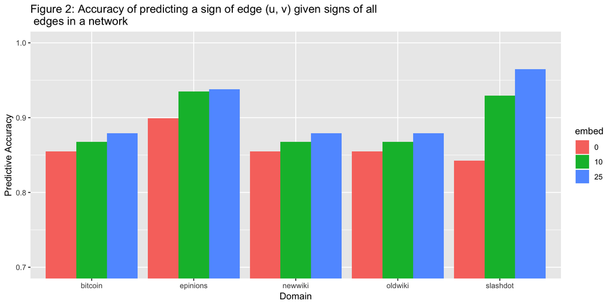

```r
# produce visuali
pred_acc_chunk_nw <- cbind(c("0","10","25"), pred_accuracy_newwiki, c("newwiki", "newwiki", "newwiki"))
pred_acc_chunk_bc <- cbind(c("0","10","25"), pred_accuracy_bitcoin, c("bitcoin", "bitcoin", "bitcoin"))

reformatted_pred_acc <- rbind(pred_acc_chunk_ep, pred_acc_chunk_sl, pred_acc_chunk_ow, pred_acc_chunk_nw, pred_acc_chunk_bc)
reformatted_pred_acc <- as_tibble(reformatted_pred_acc)

colnames(reformatted_pred_acc) <- c("embed", "predacc", "website")

reformatted_pred_acc <- reformatted_pred_acc %>%
  mutate(predacc = as.numeric(predacc))

ggplot(data = reformatted_pred_acc, aes(website, predacc)) +
  geom_bar(aes(fill = embed), position = "dodge", stat = "identity") +
  coord_cartesian(ylim=c(.7, 1)) +
  labs(y = 'Predictive Accuracy', x = 'Domain', title = 'Figure 2: Accuracy of predicting a sign of edge (u, v) given signs of all \n edges in a network')
```

```r
temp_x4 <- test_newwiki[,-c(1,2,3)]
temp_y4 <- test_newwiki[,3]

mylogit_newwiki <-cv.glmnet(as.matrix(temp_x4),temp_y4, family = "binomial")

cross_predict(mylogit_wiki_old,test_newwiki)
```

```
##
##         0     1
##   0 13595  1892
##   1  2086 17681
## [1] 0.8871617
```

```
## [1] 0.8871617
```

```r
cross_predict(mylogit_slashdot, test_newwiki)
```

```
##
##         0     1
##   0 12610   548
##   1  3071 19025
## [1] 0.897345
```

```
## [1] 0.897345
```

```r
cross_predict(mylogit_epinions, test_newwiki)
```

```
##
##         0     1
##   0 11140  1744
##   1  4541 17829
## [1] 0.8217224
```

```
## [1] 0.8217224
```

```r
cross_predict(mylogit_newwiki, test)
```

```
##
##         0     1
##   0  5302  4472
##   1 10808 48749
## [1] 0.779608
```

```
## [1] 0.779608
```

```r
cross_predict(mylogit_newwiki, test_slashdot)
```

```
##
##          0      1
##   0  33968  15411
##   1  19971 158562
## [1] 0.8447559
```

```
## [1] 0.8447559
```

```r
cross_predict(mylogit_newwiki, test_epinions)
```

```
##
##          0      1
##   0  56302  15111
##   1  24276 268285
## [1] 0.8917862
```

```
## [1] 0.8917862
```

```r
temp_x5 <- test_bitcoin[,-c(1,2,3)]
temp_y5 <- test_bitcoin[,3]

mylogit_bitcoin <-cv.glmnet(as.matrix(temp_x5), temp_y5, family = "binomial")

cross_predict(mylogit_wiki_old,test_bitcoin)
```

```
##
##         0     1
##   0  1511  7741
##   1  1731 10508
## [1] 0.5592574
```

```
## [1] 0.5592574
```

```r
cross_predict(mylogit_slashdot, test_bitcoin)
```

```
##
##         0     1
##   0  1383  6756
##   1  1859 11493
## [1] 0.5991345
```

```
## [1] 0.5991345
```

```r
cross_predict(mylogit_epinions, test_bitcoin)
```

```
##
##         0     1
##   0   943  3839
##   1  2299 14410
## [1] 0.7143921
```

```
## [1] 0.7143921
```

```r
cross_predict(mylogit_newwiki, test_bitcoin)
```

```
##
##         0     1
##   0  2434 12619
##   1   808  5630
## [1] 0.3752268
```

```
## [1] 0.3752268
```

```r
cross_predict(mylogit_bitcoin, test)
```

```
##
##         0     1
##   0   128  1430
##   1 15982 51791
## [1] 0.7488569
```

```
## [1] 0.7488569
```

```r
cross_predict(mylogit_bitcoin, test_slashdot)
```

```
##
##          0      1
##   0      4    665
##   1  53935 173308
## [1] 0.7604339
```

```
## [1] 0.7604339
```

```r
cross_predict(mylogit_bitcoin, test_epinions)
```

```
##
##          0      1
##   0   1144  20190
##   1  79434 263206
## [1] 0.7262881
```

```
## [1] 0.7262881
```

```r
cross_predict(mylogit_bitcoin, test_newwiki)
```

```
##
##         0     1
##   0   420   181
##   1 15261 19392
## [1] 0.5619788
```

```
## [1] 0.5619788
```

## CONCLUSIONS

We ran into a number of challenges attempting to reproduce this paper. First, although clearly mentioned by Leskovec et. al, no reproducibility code was found online. This required a us to put a substantial amount of work into generating a features for each dataset and implementing a framework for edge prediction. In addition, the incredibly vague explanation of how data from Wikipedia was collected ultimately required us to write our own web scraper to collect new data for extension. Although all of our other data sets were publicly available on SNAP and were explicitly cited in Leskovec et. al (2010), these data sets all differed slightly from their description in the paper. These challenges introduce a number of possible explanations for the slight variation between our replicated results and those found in the paper. It is possible that the prediction framework were developed differed from that used in the original paper; data uploaded on SNAP could differ significantly from that actually used by Leskovec et. al; similarly our newly collected data could have followed a different collection protocol resulting in a network that is not a direct extension of that used in the original paper. While these concerns are valid, our somewhat differing replicated results do not directly contradict those found by Leskovec et. al and suggest that many of their general conclusions based on these data sets are correct.